# Project 2: Public Health & Epidemiology

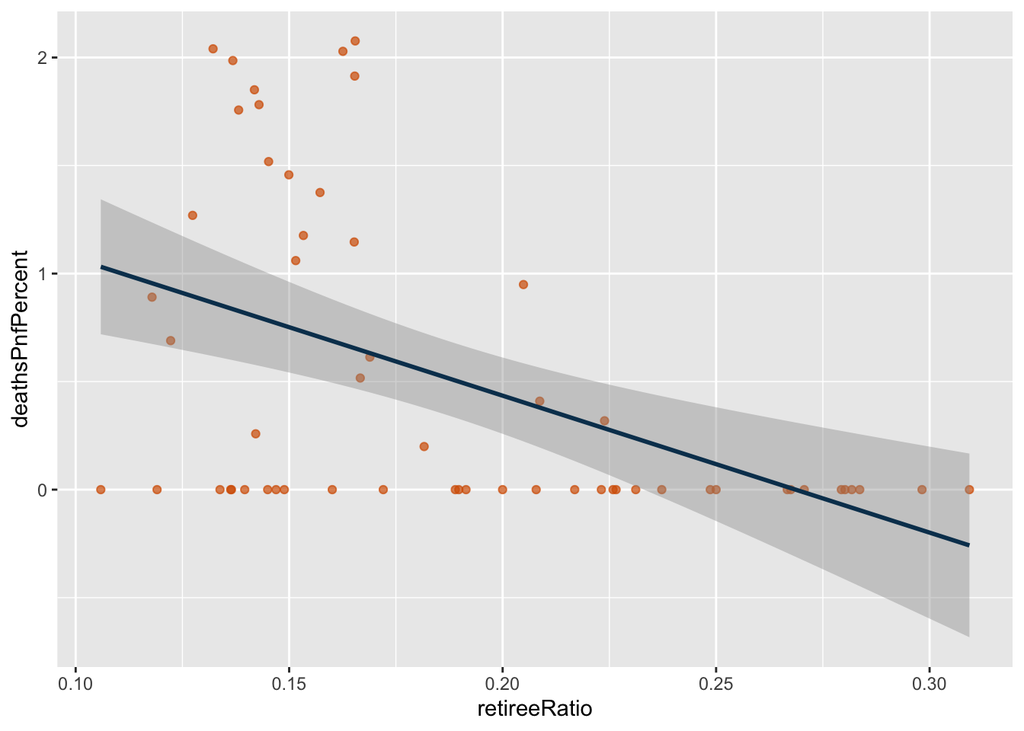

```r
pnfDeaths %>%
  group_by(County) %>%
  summarise(retireeRatio = mean(retireeRatio),
            deathsPnfPercent = mean(deathsPnfProportion, na.rm = TRUE)*100) %>%
  ggplot(aes(x = retireeRatio, y = deathsPnfPercent)) +
  geom_point(alpha = 0.7, color = skittles[5]) +
  geom_smooth(color = skittles[8], method = "lm")
```

```r
pnfCounty <- pnfDeaths %>%
  group_by(County) %>%
  summarise(retireeRatio = mean(retireeRatio),
            deathsPnfPercent = mean(deathsPnfProportion, na.rm = TRUE) * 100,
            .groups = "drop")
cor.test(pnfCounty$retireeRatio, pnfCounty$deathsPnfPercent)
```

```
##
##  Pearson's product-moment correlation
##
## data:  pnfCounty$retireeRatio and pnfCounty$deathsPnfPercent
## t = -3.9798, df = 55, p-value = 0.0002038
## alternative hypothesis: true correlation is not equal to 0
## 95 percent confidence interval:
##  -0.6529648 -0.2421108
## sample estimates:
##        cor
## -0.4728482
```

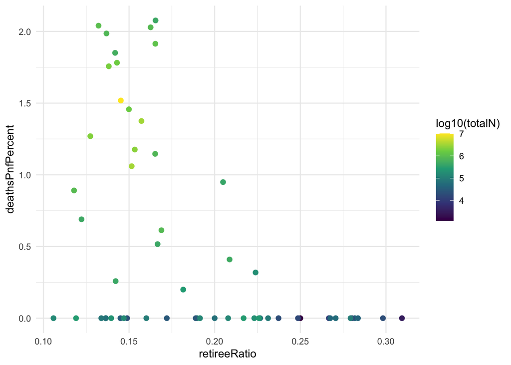

```r
pnfCounty <- pnfCounty %>% left_join(census %>% select(County, totalN), by = "County")

## color the scatter by population to see the small-county zeros
ggplot(pnfCounty, aes(retireeRatio, deathsPnfPercent, color = log10(totalN))) +
  geom_point(size = 2) + scale_color_viridis_c() + theme_minimal()
```

```r
## and re-test among counties large enough to avoid suppression
cor.test(~ retireeRatio + deathsPnfPercent, data = filter(pnfCounty, totalN > 2e5))
```

```
##
##  Pearson's product-moment correlation
##
## data:  retireeRatio and deathsPnfPercent
## t = -2.1, df = 26, p-value = 0.04558
## alternative hypothesis: true correlation is not equal to 0
## 95 percent confidence interval:
##  -0.660107402 -0.009018112
## sample estimates:
##        cor
## -0.3808138
```

4. **Interpretation** of all graphs or analyses explored.

**Answer:** What I could learn from all graphs for now, pneumonia makes up a bigger slice of deaths in the larger southern and inland counties: San Bernardino, Riverside, Imperial, and a band through the Central Valley and the pattern stays pretty stable year to year.The grey and cream counties up north aren’t pneumonia-free; they’re just small enough that the monthly, sex-split counts get suppressed for privacy and come through as zero. So the maps are really only telling me about the bigger counties. There’s a little bump in 2020, San Bernardino slides into the darkest bin, but flu seasons bounce around from year to year anyway, so I wouldn’t lean on that too hard.

The line graph is where the COVID story falls apart to me. Summing all the counties together by month gives a clean seasonal wave: pneumonia peaks every winter and drops off in summer, and the rough 2017–18 flu season sticks out as the tallest January. But 2020 doesn’t spike. It rides along with the other years in winter and then sits near the bottom through spring and summer. That threw me until I remembered that COVID deaths got their own code (U07.1), so they never landed in the pneumonia bucket, and on top of that, COVID drove total deaths way up, and that’s the denominator. So pneumonia’s share of deaths goes down in 2020 even though more people were dying. The pandemic shows up here as a dip, not a spike, which is the opposite of what we’d guess.

The scatter tell another different story to me. Older counties have a lower pneumonia share, not higher, the correlation came out negative (−0.47), backwards from everything we know about pneumonia hitting the elderly hardest. Digging in, two things were going on. The obvious one is suppression again: the oldest counties are the small rural retirement ones (Amador, Calaveras, that crowd), and they’re suppressed to zero. But even after I narrowed it to just the big counties, the negative stuck around (−0.38), so it’s not only an artifact. The counties carrying the high pneumonia share are the younger, bigger, inland ones, and that probably has more to do with air quality, income, and healthcare access out there than with age, though those are things I’d want to test, not just assert. It’s a clean case of the ecological fallacy: pneumonia really does hit older people harder, but older counties don’t have higher pneumonia shares, because at the county level you’re looking at the whole mix of deaths, not individual risk. Put together, the three pieces say the same thing: the share of deaths from pneumonia isn’t driven by the obvious suspects, the pandemic, or how old the county is, so much as by how the data get coded and suppressed, and by what kind of county you’re looking at. The one thing that’s solid and survives all of it is the seasonality.

5. **A data science question you would like to test**

**Answer:** Does a California county’s over-65 share genuinely predict its pneumonia/influenza death proportion, or does that association disappear once I control for population size and for the socioeconomic, healthcare-access, and air-quality differences that distinguish younger inland counties from older coastal ones?

6. **A data science hypothesis based on what you found** [Note: if you find nothing compelling, you may defend with evidence why there is no point developing a hypothesis instead.]

**Answer:** My hypothesis is that a county’s age structure isn’t really what drives pneumonia’s share of deaths. I think the negative correlation I found is mostly a product of suppression and confounding rather than a true effect of age. If I controlled for population size, I’d expect the association to drop sharply, because the small, old counties that get suppressed to zero are what pull it most negative to begin with. Once I brought in the kinds of variables that set younger inland counties apart, like socioeconomic status, healthcare access, and air quality, I’d expect whatever negative is left to shrink toward zero or stop being significant. So my prediction is that the share of residents over 65 ends up a weak or insignificant predictor once those variables are in the model, and certainly not the positive predictor you’d expect from how hard pneumonia hits the elderly. If anything still predicts pneumonia’s share, my money is on the type of county itself, meaning the younger, lower income, inland counties that seem to carry more of it, rather than age. Two outcomes would prove me wrong. If the share of residents over 65 stayed strongly negative even after all of those controls, I’d have to treat it as a real county effect rather than an artifact. And if it flipped positive once the confounders were in, that would tell me those variables had been hiding the individual risk all along.